# Topic 1 Exercises

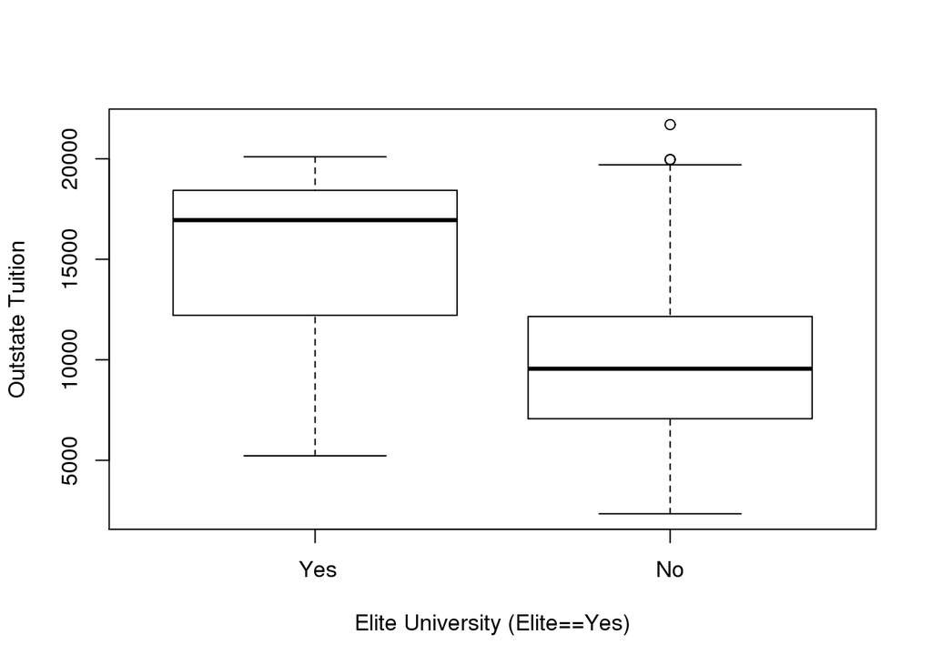

```r
boxplot(College$Outstate~College$Elite, xlab="Elite University (Elite==Yes)", ylab="Outstate Tuition")
```

**v. Use the hist() function to produce some histograms with differing numbers of bins for a few of the quantitative variables.**

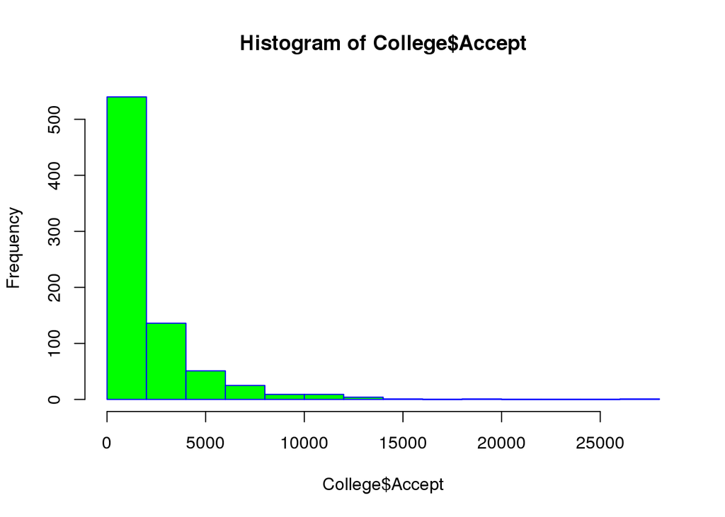

```r
hist(College$Accept,border="blue",col="green")
```

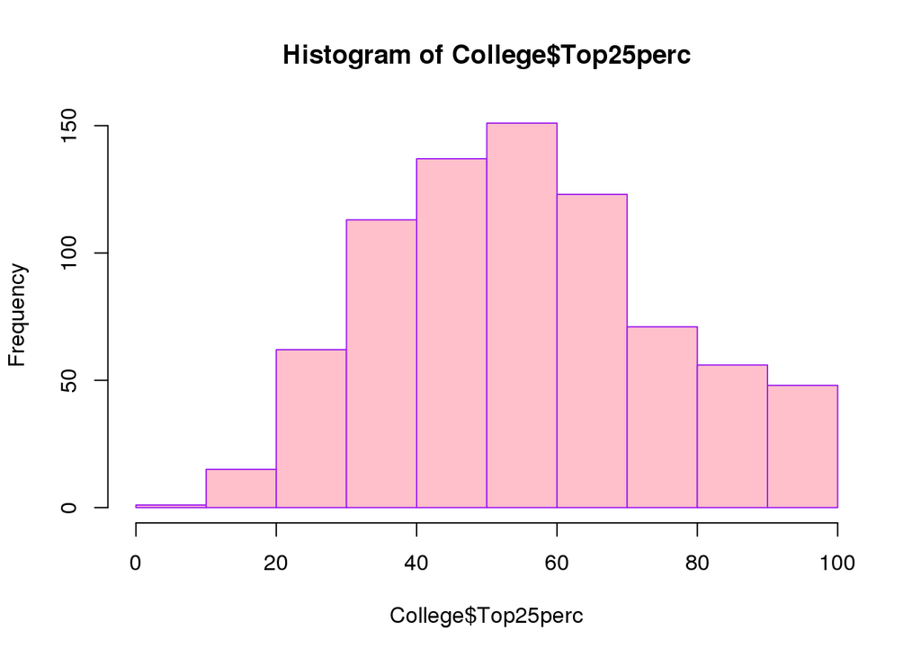

```r
hist(College$Top25perc, border="purple",col="pink")
```

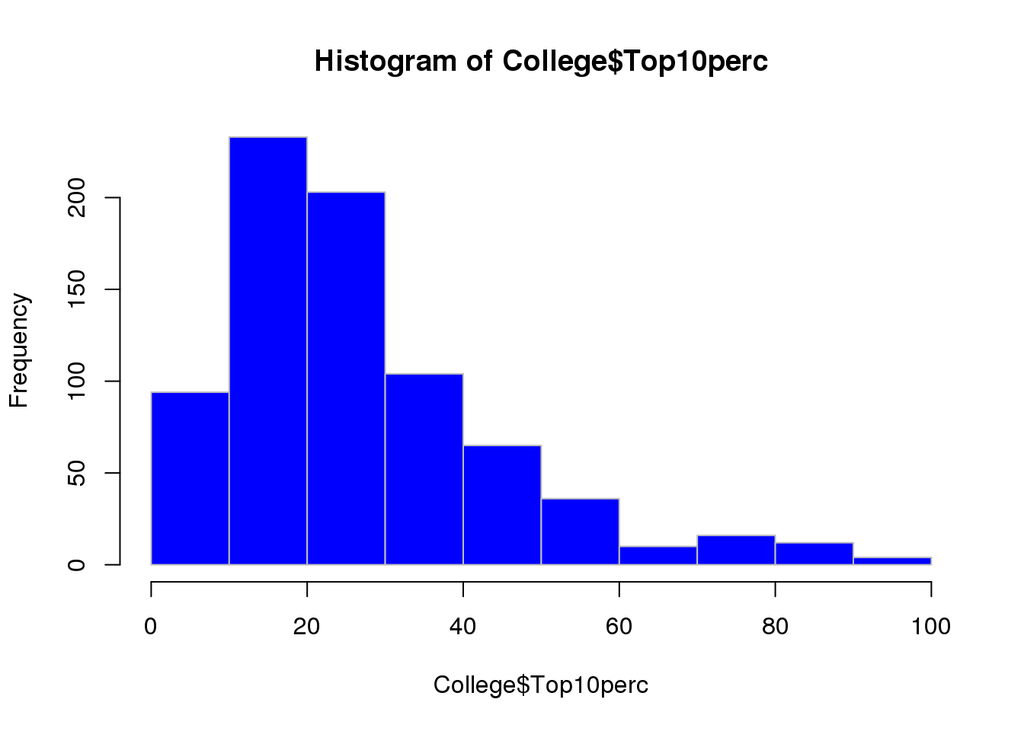

```r
hist(College$Top10perc,border="grey",col="blue")
```

**vi. Continue exploring the data, and provide a brief summary of what you discover** Exploration #1:

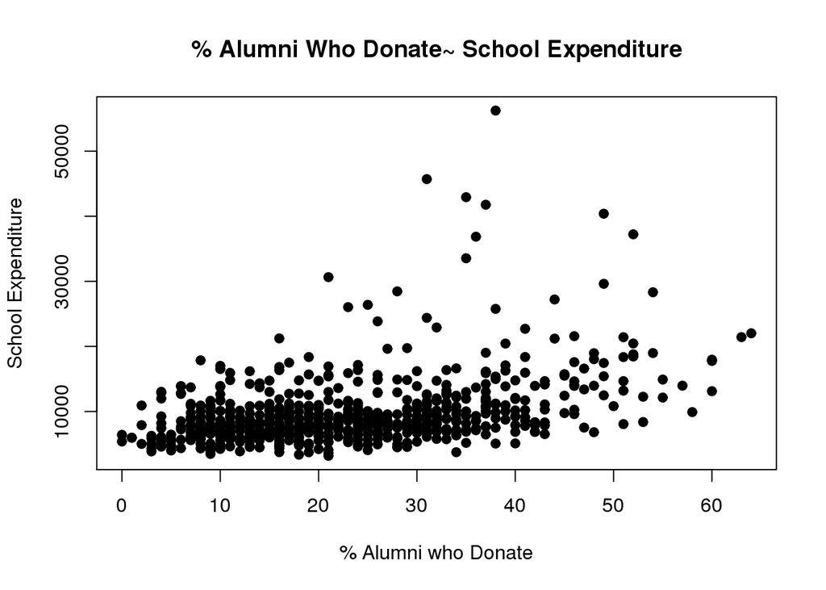

```r
plot(College$perc.alumni, College$Expend,main="% Alumni Who Donate~ School Expenditure",
    xlab="% Alumni who Donate", ylab="School Expenditure", pch=19)
```

[figure not shown]

```r
plot(College$perc.alumni, College$S.F.Ratio,main="% Alumni Who Donate~ School Expenditure",
    xlab="% Alumni who Donate", ylab="Student Faculty Ratio", pch=19)
```

There is a slight negative relationship between student-faculty ratio and % alumni who donate. Meaning, the smaller the class room, the more likely it is for an alumni to donate back to the school

Exploration #3:

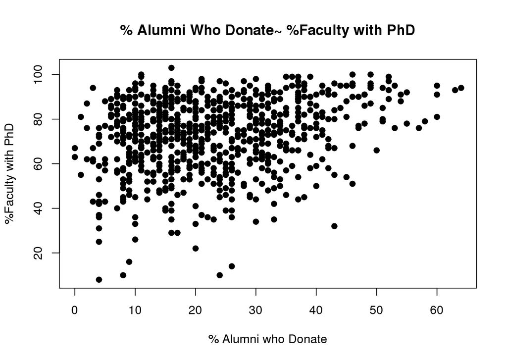

```r
plot(College$perc.alumni, College$PhD,main="% Alumni Who Donate~ %Faculty with PhD",
    xlab="% Alumni who Donate", ylab="%Faculty with PhD", pch=19)
```

There is no clear relationship between % of faculty with PhDs and % alumni who donate.